# Capstone_Project_2_Semiconductor_Yield

<h1 id="Capstone-Project-2-%E2%80%94-Semiconductor-Manufacturing-Process-Yield-Prediction">Capstone Project 2 — Semiconductor Manufacturing Process Yield Prediction</h1><p>**Domain:** Semiconductor Manufacturing Process<br /> **Objective:** Build a professional classification workflow to predict Pass/Fail yield and determine whether all measured sensor signals are required.</p> <h3 id="Business-context">Business context</h3><p>The dataset contains sensor/process measurements from semiconductor production entities. The target `Pass/Fail` uses `-1 = Pass` and `1 = Fail`. Because Fail observations are rare, model evaluation emphasizes the **Fail class** rather than accuracy alone.</p> <h3 id="Project-workflow">Project workflow</h3>

1. Import and explore the data
2. Data cleansing and logical feature reduction
3. Statistical, univariate, bivariate and multivariate analysis
4. Leakage-safe preprocessing, train/test split and SMOTE
5. Train, cross-validate and tune multiple supervised models
6. Compare models and select the final model using training cross-validation
7. Save the complete preprocessing + model pipeline
8. Conclusion and business-oriented recommendations

> <p>**Reproducibility:** `RANDOM_STATE = 42` is used throughout. Run the notebook from top to bottom in a fresh kernel.</p>

<h3 id="Approach">Approach</h3><p>The project follows a complete machine learning workflow: data exploration, data cleansing, exploratory data analysis, leakage-aware preprocessing, feature reduction, standardisation, SMOTE-based class balancing, cross-validation, GridSearch hyperparameter tuning, and evaluation of multiple supervised learning models.</p> <h3 id="Models-Evaluated">Models Evaluated</h3>

- Logistic Regression
- Random Forest
- Support Vector Machine (SVM)
- Gaussian Naive Bayes
- Random Forest with PCA enhancement

<h3 id="Evaluation">Evaluation</h3><p>Models are compared using accuracy, precision, recall, F1-score and ROC-AUC. Because Fail cases are the minority class, particular attention is given to the Fail-class F1-score and recall rather than accuracy alone.</p> <h3 id="Business-Relevance">Business Relevance</h3><p>The analysis aims to identify whether all measured signals are necessary for yield prediction and to determine whether a reduced set of informative signals can support semiconductor yield monitoring.</p> <h3 id="Key-Finding">Key Finding</h3><p>The results demonstrate the difficulty of predicting the relatively rare Fail class and highlight the importance of appropriate preprocessing, class-balancing techniques and minority-class evaluation in semiconductor yield prediction.</p>

```python
# 0. Imports and configuration
import os
import warnings
warnings.filterwarnings("ignore")

import numpy as np
import pandas as pd
import matplotlib.pyplot as plt
import seaborn as sns
import joblib

from sklearn.base import BaseEstimator, TransformerMixin
from sklearn.model_selection import train_test_split, StratifiedKFold, GridSearchCV
from sklearn.preprocessing import StandardScaler
from sklearn.impute import SimpleImputer
from sklearn.pipeline import Pipeline
from sklearn.decomposition import PCA
from sklearn.linear_model import LogisticRegression
from sklearn.ensemble import RandomForestClassifier
from sklearn.svm import SVC
from sklearn.naive_bayes import GaussianNB
from sklearn.metrics import (
    accuracy_score, precision_score, recall_score, f1_score,
    roc_auc_score, classification_report, confusion_matrix
)
from imblearn.over_sampling import SMOTE
from imblearn.pipeline import Pipeline as ImbPipeline

RANDOM_STATE = 42
DATA_PATH = "signal-data.csv"

pd.set_option("display.max_columns", 20)
pd.set_option("display.float_format", lambda x: f"{x:.4f}")

print("Environment ready.")
print("Random state:", RANDOM_STATE)
```

```
Environment ready.
Random state: 42
```

<h2 id="1.-Import-and-Explore-the-Data">1. Import and Explore the Data</h2>

```python
df = pd.read_csv(DATA_PATH)

print("Raw dataset shape:", df.shape)
print("\nFirst five rows:")
display(df.head())

print("\nData types:")
display(df.dtypes.value_counts())

print("\nTarget distribution:")
display(df["Pass/Fail"].value_counts().rename(index={-1:"Pass (-1)", 1:"Fail (1)"}))

print("\nTarget proportions:")
display(df["Pass/Fail"].value_counts(normalize=True).rename(index={-1:"Pass (-1)", 1:"Fail (1)"}).round(4))
```

```
Raw dataset shape: (1567, 592)

First five rows:
```

<style scoped> .dataframe tbody tr th:only-of-type { vertical-align: middle; } .dataframe tbody tr th { vertical-align: top; } .dataframe thead th { text-align: right; } </style> <thead> <th></th> <th>Time</th> <th>0</th> <th>1</th> <th>2</th> <th>3</th> <th>4</th> <th>5</th> <th>6</th> <th>7</th> <th>8</th> <th>...</th> <th>581</th> <th>582</th> <th>583</th> <th>584</th> <th>585</th> <th>586</th> <th>587</th> <th>588</th> <th>589</th> <th>Pass/Fail</th> </thead> <tbody> <th>0</th> <th>1</th> <th>2</th> <th>3</th> <th>4</th> </tbody>

| 2008-07-19 11:55:00 | 3030.9300 | 2564.0000 | 2187.7333 | 1411.1265 | 1.3602 | 100.0000 | 97.6133 | 0.1242 | 1.5005 | ... | NaN | 0.5005 | 0.0118 | 0.0035 | 2.3630 | NaN | NaN | NaN | NaN | -1 |
| --- | --- | --- | --- | --- | --- | --- | --- | --- | --- | --- | --- | --- | --- | --- | --- | --- | --- | --- | --- | --- |
| 2008-07-19 12:32:00 | 3095.7800 | 2465.1400 | 2230.4222 | 1463.6606 | 0.8294 | 100.0000 | 102.3433 | 0.1247 | 1.4966 | ... | 208.2045 | 0.5019 | 0.0223 | 0.0055 | 4.4447 | 0.0096 | 0.0201 | 0.0060 | 208.2045 | -1 |
| 2008-07-19 13:17:00 | 2932.6100 | 2559.9400 | 2186.4111 | 1698.0172 | 1.5102 | 100.0000 | 95.4878 | 0.1241 | 1.4436 | ... | 82.8602 | 0.4958 | 0.0157 | 0.0039 | 3.1745 | 0.0584 | 0.0484 | 0.0148 | 82.8602 | 1 |
| 2008-07-19 14:43:00 | 2988.7200 | 2479.9000 | 2199.0333 | 909.7926 | 1.3204 | 100.0000 | 104.2367 | 0.1217 | 1.4882 | ... | 73.8432 | 0.4990 | 0.0103 | 0.0025 | 2.0544 | 0.0202 | 0.0149 | 0.0044 | 73.8432 | -1 |
| 2008-07-19 15:22:00 | 3032.2400 | 2502.8700 | 2233.3667 | 1326.5200 | 1.5334 | 100.0000 | 100.3967 | 0.1235 | 1.5031 | ... | NaN | 0.4800 | 0.4766 | 0.1045 | 99.3032 | 0.0202 | 0.0149 | 0.0044 | 73.8432 | -1 |

<p>5 rows × 592 columns</p>

```
Data types:
```

```
float64    590
str          1
int64        1
Name: count, dtype: int64
```

```
Target distribution:
```

```
Pass/Fail
Pass (-1)    1463
Fail (1)      104
Name: count, dtype: int64
```

```
Target proportions:
```

```
Pass/Fail
Pass (-1)   0.9336
Fail (1)    0.0664
Name: proportion, dtype: float64
```

```python
print("Duplicate rows:", df.duplicated().sum())
print("Total missing cells:", int(df.isna().sum().sum()))
print("Columns with missing values:", int((df.isna().sum() > 0).sum()))

missing_summary = pd.DataFrame({
    "missing_count": df.isna().sum(),
    "missing_pct": df.isna().mean() * 100
}).sort_values("missing_pct", ascending=False)

display(missing_summary.head(15))
```

```
Duplicate rows: 0
Total missing cells: 41951
Columns with missing values: 538
```

<style scoped> .dataframe tbody tr th:only-of-type { vertical-align: middle; } .dataframe tbody tr th { vertical-align: top; } .dataframe thead th { text-align: right; } </style> <thead> <th></th> <th>missing_count</th> <th>missing_pct</th> </thead> <tbody> <th>293</th> <th>292</th> <th>157</th> <th>158</th> <th>492</th> <th>220</th> <th>85</th> <th>358</th> <th>518</th> <th>382</th> <th>245</th> <th>244</th> <th>383</th> <th>384</th> <th>246</th> </tbody>

| 1429 | 91.1934 |
| --- | --- |
| 1429 | 91.1934 |
| 1429 | 91.1934 |
| 1429 | 91.1934 |
| 1341 | 85.5775 |
| 1341 | 85.5775 |
| 1341 | 85.5775 |
| 1341 | 85.5775 |
| 1018 | 64.9649 |
| 1018 | 64.9649 |
| 1018 | 64.9649 |
| 1018 | 64.9649 |
| 1018 | 64.9649 |
| 1018 | 64.9649 |
| 1018 | 64.9649 |

<h2 id="2.-Data-Cleansing">2. Data Cleansing</h2>

```python
# Separate target and timestamp from predictive sensor measurements.
y = df["Pass/Fail"].astype(int)
X_raw = df.drop(columns=["Pass/Fail", "Time"])

print("Sensor feature matrix:", X_raw.shape)
print("Target shape:", y.shape)
```

```
Sensor feature matrix: (1567, 590)
Target shape: (1567,)
```

```python
# Descriptive cleansing diagnostics
missing_pct = X_raw.isna().mean() * 100
high_missing_cols = missing_pct[missing_pct > 40].index.tolist()

zero_variance_cols = X_raw.nunique(dropna=True)
zero_variance_cols = zero_variance_cols[zero_variance_cols <= 1].index.tolist()

print(f"Features before cleansing: {X_raw.shape[1]}")
print(f"Features with >40% missing values: {len(high_missing_cols)}")
print(f"Zero/one-unique-value features: {len(zero_variance_cols)}")
print(f"Unique target values: {sorted(y.unique().tolist())}")
```

```
Features before cleansing: 590
Features with >40% missing values: 32
Zero/one-unique-value features: 116
Unique target values: [-1, 1]
```

```python
# EDA-level cleaned view for descriptive analysis.
# Model preprocessing below is fitted ONLY on the training data to prevent leakage.
eda_drop = sorted(set(high_missing_cols + zero_variance_cols))
X_eda = X_raw.drop(columns=eda_drop).copy()
X_eda = X_eda.fillna(X_eda.median(numeric_only=True))

print("EDA feature count after missing/constant filtering:", X_eda.shape[1])
print("Remaining missing values:", int(X_eda.isna().sum().sum()))
```

```
EDA feature count after missing/constant filtering: 442
Remaining missing values: 0
```

<p>**Cleansing logic:**</p>

- `Time` is excluded because it is a timestamp rather than a process measurement.
- Features with more than 40% missing values are removed because reliable imputation becomes difficult.
- Constant/near-constant signals with no useful variation are removed.
- Remaining missing numeric values are represented by their median for exploratory analysis.
- A correlation-reduction step is used inside the model preprocessing and is **fitted only on training data**, avoiding test-set information leakage.

<h2 id="3.-Data-Analysis-&-Visualisation">3. Data Analysis & Visualisation</h2>

<h3 id="3.1-Statistical-Analysis">3.1 Statistical Analysis</h3>

```python
stats = X_eda.describe().T
stats["missing_pct"] = X_eda.isna().mean() * 100
display(stats[["count","mean","std","min","25%","50%","75%","max","missing_pct"]].head(15))
```

<style scoped> .dataframe tbody tr th:only-of-type { vertical-align: middle; } .dataframe tbody tr th { vertical-align: top; } .dataframe thead th { text-align: right; } </style> <thead> <th></th> <th>count</th> <th>mean</th> <th>std</th> <th>min</th> <th>25%</th> <th>50%</th> <th>75%</th> <th>max</th> <th>missing_pct</th> </thead> <tbody> <th>0</th> <th>1</th> <th>2</th> <th>3</th> <th>4</th> <th>6</th> <th>7</th> <th>8</th> <th>9</th> <th>10</th> <th>11</th> <th>12</th> <th>14</th> <th>15</th> <th>16</th> </tbody>

| 1567.0000 | 3014.4416 | 73.4808 | 2743.2400 | 2966.6650 | 3011.4900 | 3056.5400 | 3356.3500 | 0.0000 |
| --- | --- | --- | --- | --- | --- | --- | --- | --- |
| 1567.0000 | 2495.8661 | 80.2281 | 2158.7500 | 2452.8850 | 2499.4050 | 2538.7450 | 2846.4400 | 0.0000 |
| 1567.0000 | 2200.5520 | 29.3810 | 2060.6600 | 2181.0999 | 2201.0667 | 2218.0555 | 2315.2667 | 0.0000 |
| 1567.0000 | 1395.3835 | 439.8373 | 0.0000 | 1083.8858 | 1285.2144 | 1590.1699 | 3715.0417 | 0.0000 |
| 1567.0000 | 4.1713 | 56.1037 | 0.6815 | 1.0177 | 1.3168 | 1.5188 | 1114.5366 | 0.0000 |
| 1567.0000 | 101.1165 | 6.2094 | 82.1311 | 97.9378 | 101.5122 | 104.5300 | 129.2522 | 0.0000 |
| 1567.0000 | 0.1218 | 0.0089 | 0.0000 | 0.1211 | 0.1224 | 0.1238 | 0.1286 | 0.0000 |
| 1567.0000 | 1.4629 | 0.0738 | 1.1910 | 1.4112 | 1.4616 | 1.5168 | 1.6564 | 0.0000 |
| 1567.0000 | -0.0008 | 0.0151 | -0.0534 | -0.0108 | -0.0013 | 0.0084 | 0.0749 | 0.0000 |
| 1567.0000 | 0.0001 | 0.0093 | -0.0349 | -0.0056 | 0.0004 | 0.0059 | 0.0530 | 0.0000 |
| 1567.0000 | 0.9644 | 0.0124 | 0.6554 | 0.9581 | 0.9658 | 0.9713 | 0.9848 | 0.0000 |
| 1567.0000 | 199.9563 | 3.2552 | 182.0940 | 198.1309 | 199.5356 | 202.0068 | 272.0451 | 0.0000 |
| 1567.0000 | 9.0053 | 2.7939 | 2.2493 | 7.0968 | 8.9670 | 10.8587 | 19.5465 | 0.0000 |
| 1567.0000 | 413.0844 | 17.2046 | 333.4486 | 406.1310 | 412.2191 | 419.0828 | 824.9271 | 0.0000 |
| 1567.0000 | 9.9075 | 2.4016 | 4.4696 | 9.5686 | 9.8517 | 10.1278 | 102.8677 | 0.0000 |

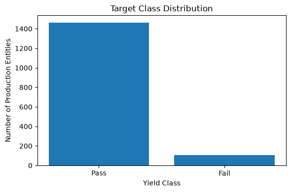

```
Pass rate: 93.36%
Fail rate: 6.64%
Imbalance ratio (Pass:Fail): 14.1:1
```

```python
# Target distribution
counts = y.map({-1:"Pass", 1:"Fail"}).value_counts().reindex(["Pass","Fail"])
plt.figure(figsize=(6,4))
plt.bar(counts.index, counts.values)
plt.title("Target Class Distribution")
plt.xlabel("Yield Class")
plt.ylabel("Number of Production Entities")
plt.tight_layout()
plt.show()

print(f"Pass rate: {(y == -1).mean():.2%}")
print(f"Fail rate: {(y == 1).mean():.2%}")
print(f"Imbalance ratio (Pass:Fail): {(y == -1).sum() / (y == 1).sum():.1f}:1")
```

<p>**Statistical comment:** The target distribution is highly imbalanced. A classifier can obtain high raw accuracy by over-predicting Pass, so Fail precision, recall, F1 and ROC-AUC are retained as primary diagnostic metrics.</p>

<h3 id="3.2-Univariate-Analysis">3.2 Univariate Analysis</h3>

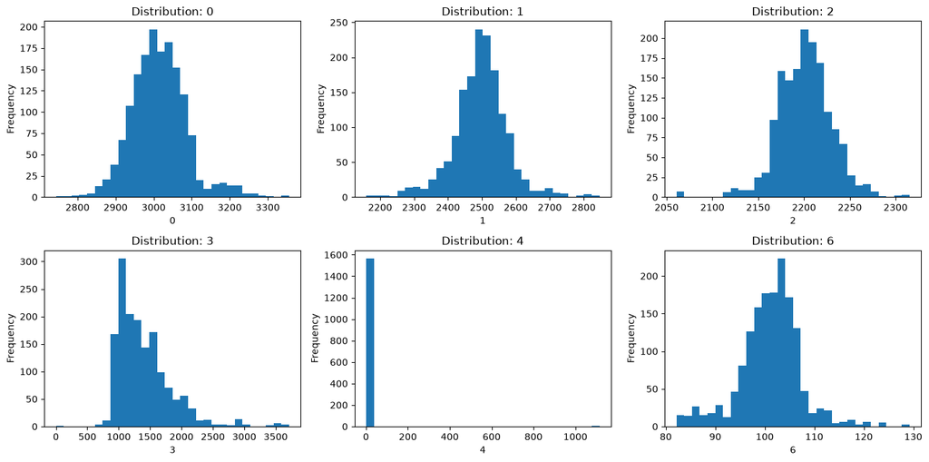

```python
sample_cols = X_eda.columns[:6]
fig, axes = plt.subplots(2, 3, figsize=(14,7))
for ax, col in zip(axes.ravel(), sample_cols):
    ax.hist(X_eda[col].dropna(), bins=30)
    ax.set_title(f"Distribution: {col}")
    ax.set_xlabel(col)
    ax.set_ylabel("Frequency")
plt.tight_layout()
plt.show()
```

<p>**Univariate comment:** Sensor distributions can differ substantially in scale and shape. This supports later standardisation for distance/margin-based models such as Logistic Regression and SVM. The plots are representative rather than a plot of all hundreds of signals.</p>

<h3 id="3.3-Bivariate-Analysis">3.3 Bivariate Analysis</h3>

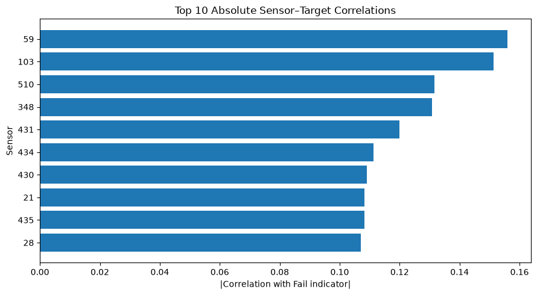

<style scoped> .dataframe tbody tr th:only-of-type { vertical-align: middle; } .dataframe tbody tr th { vertical-align: top; } .dataframe thead th { text-align: right; } </style> <thead> <th></th> <th>absolute_correlation</th> </thead> <tbody> <th>59</th> <th>103</th> <th>510</th> <th>348</th> <th>431</th> <th>434</th> <th>430</th> <th>21</th> <th>435</th> <th>28</th> </tbody>

| 0.1560 |
| --- |
| 0.1512 |
| 0.1317 |
| 0.1308 |
| 0.1199 |
| 0.1113 |
| 0.1091 |
| 0.1083 |
| 0.1083 |
| 0.1070 |

```python
# Correlation with binary target as a screening diagnostic.
y_binary = y.map({-1:0, 1:1})
target_corr = X_eda.corrwith(y_binary).abs().sort_values(ascending=False)

top10 = target_corr.head(10).sort_values()
plt.figure(figsize=(9,5))
plt.barh(top10.index, top10.values)
plt.title("Top 10 Absolute Sensor–Target Correlations")
plt.xlabel("|Correlation with Fail indicator|")
plt.ylabel("Sensor")
plt.tight_layout()
plt.show()

display(top10.sort_values(ascending=False).to_frame("absolute_correlation"))
```

<p>**Bivariate comment:** Individual sensor-to-target correlations are screening measures, not proof of causality. Semiconductor yield failures can arise from combinations of process variables, which motivates multivariate models.</p>

<h3 id="3.4-Multivariate-Analysis">3.4 Multivariate Analysis</h3>

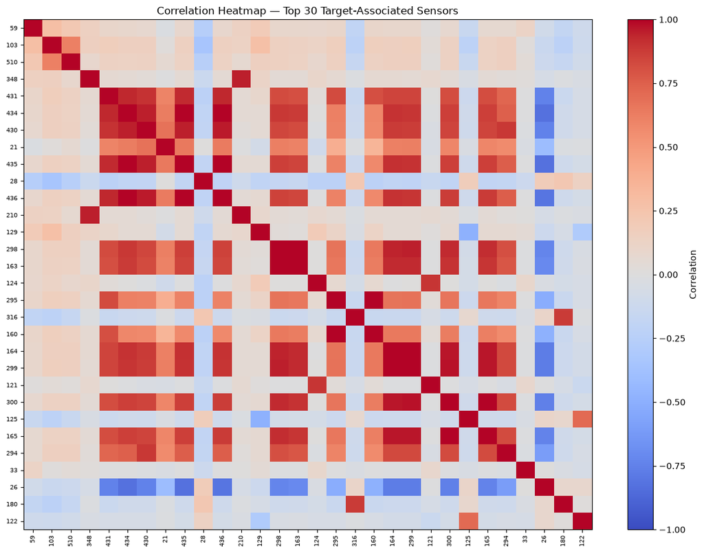

```python
# Correlation heatmap for the 30 strongest target-correlated signals.
top30_cols = target_corr.head(30).index
corr_matrix = X_eda[top30_cols].corr()
plt.figure(figsize=(12,9))
plt.imshow(corr_matrix, aspect="auto", cmap="coolwarm", vmin=-1, vmax=1)
plt.colorbar(label="Correlation")
plt.xticks(range(len(top30_cols)), top30_cols, rotation=90, fontsize=7)
plt.yticks(range(len(top30_cols)), top30_cols, fontsize=7)
plt.title("Correlation Heatmap — Top 30 Target-Associated Sensors")
plt.tight_layout()
plt.show()
```

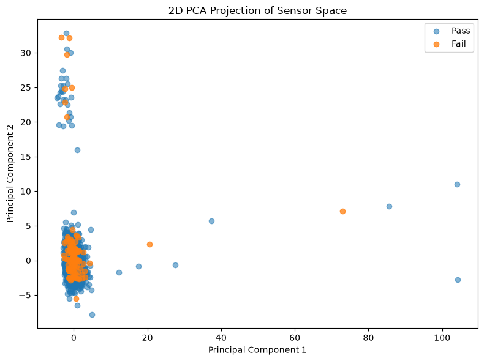

```
Variance explained by PC1 + PC2: 9.65%
```

```python
# 2D PCA is used only for visual inspection.
viz_scaler = StandardScaler()
X_viz_scaled = viz_scaler.fit_transform(X_eda)
viz_pca = PCA(n_components=2, random_state=RANDOM_STATE)
X_viz_pca = viz_pca.fit_transform(X_viz_scaled)

mask_pass = y.values == -1
mask_fail = y.values == 1
plt.figure(figsize=(8,6))
plt.scatter(X_viz_pca[mask_pass,0], X_viz_pca[mask_pass,1], alpha=0.55, label="Pass")
plt.scatter(X_viz_pca[mask_fail,0], X_viz_pca[mask_fail,1], alpha=0.75, label="Fail")
plt.title("2D PCA Projection of Sensor Space")
plt.xlabel("Principal Component 1")
plt.ylabel("Principal Component 2")
plt.legend()
plt.tight_layout()
plt.show()

print("Variance explained by PC1 + PC2:", f"{viz_pca.explained_variance_ratio_.sum():.2%}")
```

<p>**Multivariate comment:** Correlated sensor groups indicate redundancy, while a 2D PCA projection provides a compact visual view of the high-dimensional process space. Because the full feature space is much richer than two dimensions, lack of perfect visual separation does not imply that prediction is impossible.</p>

<h2 id="4.-Data-Pre-processing">4. Data Pre-processing</h2>

<h3 id="4.1-Train/Test-Split">4.1 Train/Test Split</h3>

```python
# Stratification preserves the Pass/Fail proportion in both subsets.
X_train, X_test, y_train, y_test = train_test_split(
    X_raw, y,
    test_size=0.25,
    stratify=y,
    random_state=RANDOM_STATE
)

print("Train shape:", X_train.shape)
print("Test shape :", X_test.shape)

balance = pd.DataFrame({
    "Train": y_train.value_counts(normalize=True),
    "Test": y_test.value_counts(normalize=True),
    "Original": y.value_counts(normalize=True)
}).rename(index={-1:"Pass (-1)",1:"Fail (1)"})
display(balance.round(4))
```

```
Train shape: (1175, 590)
Test shape : (392, 590)
```

<style scoped> .dataframe tbody tr th:only-of-type { vertical-align: middle; } .dataframe tbody tr th { vertical-align: top; } .dataframe thead th { text-align: right; } </style> <thead> <th></th> <th>Train</th> <th>Test</th> <th>Original</th> <th>Pass/Fail</th> <th></th> <th></th> <th></th> </thead> <tbody> <th>Pass (-1)</th> <th>Fail (1)</th> </tbody>

| 0.9336 | 0.9337 | 0.9336 |
| --- | --- | --- |
| 0.0664 | 0.0663 | 0.0664 |

<h3 id="4.2-Leakage-safe-Sensor-Preprocessor">4.2 Leakage-safe Sensor Preprocessor</h3>

```python
class SensorPreprocessor(BaseEstimator, TransformerMixin):
    """Fit data-dependent feature filtering only on the training fold."""
    def __init__(self, missing_threshold=0.40, corr_threshold=0.98):
        self.missing_threshold = missing_threshold
        self.corr_threshold = corr_threshold

    def fit(self, X, y=None):
        X = pd.DataFrame(X).copy()

        # Missingness and constant-feature rules are learned from training data only.
        missing_rate = X.isna().mean()
        self.missing_cols_ = missing_rate[missing_rate > self.missing_threshold].index.tolist()

        X1 = X.drop(columns=self.missing_cols_, errors="ignore")
        nunique = X1.nunique(dropna=True)
        self.constant_cols_ = nunique[nunique <= 1].index.tolist()

        X2 = X1.drop(columns=self.constant_cols_, errors="ignore")

        # Median imputation statistics are learned from training data only.
        self.medians_ = X2.median(numeric_only=True)

        X3 = X2.fillna(self.medians_)

        # Redundant feature removal is learned from training data only.
        corr = X3.corr().abs()
        upper = corr.where(np.triu(np.ones(corr.shape), k=1).astype(bool))
        self.corr_cols_ = [
            column for column in upper.columns
            if any(upper[column] > self.corr_threshold)
        ]

        self.feature_names_in_ = list(X.columns)
        self.feature_names_out_ = [
            c for c in X3.columns if c not in self.corr_cols_
        ]
        return self

    def transform(self, X):
        X = pd.DataFrame(X).copy()
        X = X.drop(columns=self.missing_cols_, errors="ignore")
        X = X.drop(columns=self.constant_cols_, errors="ignore")
        X = X.fillna(self.medians_)
        X = X.drop(columns=self.corr_cols_, errors="ignore")
        return X[self.feature_names_out_]

preprocessor_check = SensorPreprocessor()
preprocessor_check.fit(X_train)
X_train_clean = preprocessor_check.transform(X_train)
X_test_clean = preprocessor_check.transform(X_test)

print("Training features after leakage-safe cleansing:", X_train_clean.shape[1])
print("Test features after the same learned transformations:", X_test_clean.shape[1])
```

```
Training features after leakage-safe cleansing: 316
Test features after the same learned transformations: 316
```

<h3 id="4.3-Standardisation-and-SMOTE">4.3 Standardisation and SMOTE</h3><p>All data-dependent preprocessing is placed inside the modelling pipeline. Therefore, during cross-validation, missing-value statistics, feature filtering, scaling and SMOTE are learned from each training fold only. The held-out test set is never used to tune the model.</p> <p>**SMOTE** is applied only to the training folds to increase representation of the minority Fail class without altering the real test distribution.</p>

```python
# Compare original and split class proportions.
print("Original class counts:")
display(y.value_counts().rename(index={-1:"Pass (-1)",1:"Fail (1)"}))

print("\nTraining class counts before SMOTE:")
display(y_train.value_counts().rename(index={-1:"Pass (-1)",1:"Fail (1)"}))

print("\nTest class counts (never resampled):")
display(y_test.value_counts().rename(index={-1:"Pass (-1)",1:"Fail (1)"}))
```

```
Original class counts:
```

```
Pass/Fail
Pass (-1)    1463
Fail (1)      104
Name: count, dtype: int64
```

```
Training class counts before SMOTE:
```

```
Pass/Fail
Pass (-1)    1097
Fail (1)       78
Name: count, dtype: int64
```

```
Test class counts (never resampled):
```

```
Pass/Fail
Pass (-1)    366
Fail (1)      26
Name: count, dtype: int64
```

<h2 id="5.-Model-Training,-Testing-&-Tuning">5. Model Training, Testing & Tuning</h2>

```python
cv = StratifiedKFold(n_splits=5, shuffle=True, random_state=RANDOM_STATE)

results = {}
fitted_models = {}

def evaluate_model(name, search):
    best = search.best_estimator_
    y_pred = best.predict(X_test)
    y_score = best.predict_proba(X_test)[:, 1] if hasattr(best, "predict_proba") else best.decision_function(X_test)

    acc = accuracy_score(y_test, y_pred)
    prec = precision_score(y_test, y_pred, pos_label=1, zero_division=0)
    rec = recall_score(y_test, y_pred, pos_label=1, zero_division=0)
    f1 = f1_score(y_test, y_pred, pos_label=1, zero_division=0)
    auc = roc_auc_score((y_test == 1).astype(int), y_score)

    print(f"===== {name} =====")
    print("Best parameters:", search.best_params_)
    print(f"Best 5-fold CV Fail-F1: {search.best_score_:.4f}")
    print(f"Test Accuracy: {acc:.4f}")
    print(f"Test Precision (Fail): {prec:.4f}")
    print(f"Test Recall (Fail): {rec:.4f}")
    print(f"Test F1 (Fail): {f1:.4f}")
    print(f"Test ROC-AUC: {auc:.4f}\n")
    print(classification_report(
        y_test, y_pred,
        labels=[-1,1],
        target_names=["Pass (-1)", "Fail (1)"],
        zero_division=0
    ))

    cm = confusion_matrix(y_test, y_pred, labels=[-1,1])
    plt.figure(figsize=(4,3.5))
    plt.imshow(cm, cmap="Blues")
    plt.colorbar(label="Count")
    plt.xticks([0,1], ["Pass","Fail"])
    plt.yticks([0,1], ["Pass","Fail"])
    for r in range(2):
        for col in range(2):
            plt.text(col, r, cm[r,col], ha="center", va="center")
    plt.xlabel("Predicted")
    plt.ylabel("Actual")
    plt.title(f"{name} — Confusion Matrix")
    plt.tight_layout()
    plt.show()

    results[name] = {
        "cv_fail_f1": search.best_score_,
        "test_accuracy": acc,
        "test_precision_fail": prec,
        "test_recall_fail": rec,
        "test_f1_fail": f1,
        "test_roc_auc": auc,
        "best_params": search.best_params_
    }
    fitted_models[name] = best
```

<h3 id="5.1-Logistic-Regression">5.1 Logistic Regression</h3>

```
===== Logistic Regression =====
Best parameters: {'model__C': 10, 'model__solver': 'lbfgs'}
Best 5-fold CV Fail-F1: 0.2256
Test Accuracy: 0.8444
Test Precision (Fail): 0.1277
Test Recall (Fail): 0.2308
Test F1 (Fail): 0.1644
Test ROC-AUC: 0.6612

              precision    recall  f1-score   support

   Pass (-1)       0.94      0.89      0.91       366
    Fail (1)       0.13      0.23      0.16        26

    accuracy                           0.84       392
   macro avg       0.53      0.56      0.54       392
weighted avg       0.89      0.84      0.86       392
```

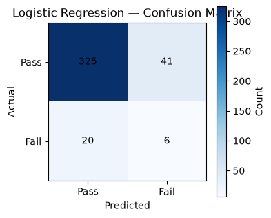

```python
lr_pipe = ImbPipeline([
    ("preprocess", SensorPreprocessor()),
    ("scale", StandardScaler()),
    ("smote", SMOTE(random_state=RANDOM_STATE)),
    ("model", LogisticRegression(max_iter=2000, random_state=RANDOM_STATE))
])

lr_grid = {
    "model__C": [0.1, 1, 10],
    "model__solver": ["liblinear", "lbfgs"]
}

lr_search = GridSearchCV(
    lr_pipe, lr_grid, cv=cv, scoring="f1", n_jobs=-1, refit=True
)
lr_search.fit(X_train, y_train)
evaluate_model("Logistic Regression", lr_search)
```

<h3 id="5.2-Random-Forest">5.2 Random Forest</h3>

```
===== Random Forest =====
Best parameters: {'model__max_depth': 10, 'model__min_samples_leaf': 2, 'model__n_estimators': 200}
Best 5-fold CV Fail-F1: 0.0865
Test Accuracy: 0.9286
Test Precision (Fail): 0.3333
Test Recall (Fail): 0.0769
Test F1 (Fail): 0.1250
Test ROC-AUC: 0.7859

              precision    recall  f1-score   support

   Pass (-1)       0.94      0.99      0.96       366
    Fail (1)       0.33      0.08      0.12        26

    accuracy                           0.93       392
   macro avg       0.64      0.53      0.54       392
weighted avg       0.90      0.93      0.91       392
```

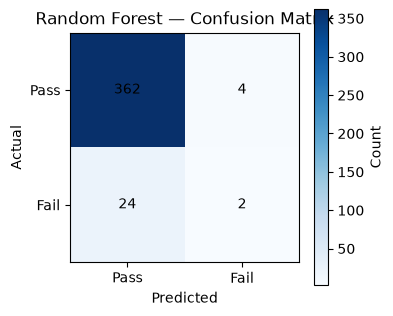

```python
rf_pipe = ImbPipeline([
    ("preprocess", SensorPreprocessor()),
    ("smote", SMOTE(random_state=RANDOM_STATE)),
    ("model", RandomForestClassifier(random_state=RANDOM_STATE, n_jobs=-1))
])

rf_grid = {
    "model__n_estimators": [100, 200],
    "model__max_depth": [None, 10, 20],
    "model__min_samples_leaf": [1, 2]
}

rf_search = GridSearchCV(
    rf_pipe, rf_grid, cv=cv, scoring="f1", n_jobs=-1, refit=True
)
rf_search.fit(X_train, y_train)
evaluate_model("Random Forest", rf_search)
```

<h3 id="5.3-Support-Vector-Machine-(SVM)">5.3 Support Vector Machine (SVM)</h3>

```
===== SVM =====
Best parameters: {'model__C': 0.5, 'model__gamma': 'auto', 'model__kernel': 'rbf'}
Best 5-fold CV Fail-F1: 0.1016
Test Accuracy: 0.9184
Test Precision (Fail): 0.2000
Test Recall (Fail): 0.0769
Test F1 (Fail): 0.1111
Test ROC-AUC: 0.6894

              precision    recall  f1-score   support

   Pass (-1)       0.94      0.98      0.96       366
    Fail (1)       0.20      0.08      0.11        26

    accuracy                           0.92       392
   macro avg       0.57      0.53      0.53       392
weighted avg       0.89      0.92      0.90       392
```

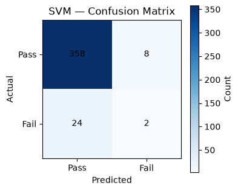

```python
svm_pipe = ImbPipeline([
    ("preprocess", SensorPreprocessor()),
    ("scale", StandardScaler()),
    ("smote", SMOTE(random_state=RANDOM_STATE)),
    ("model", SVC(probability=True, random_state=RANDOM_STATE))
])

svm_grid = {
    "model__C": [0.5, 1, 10],
    "model__gamma": ["scale", "auto"],
    "model__kernel": ["rbf"]
}

svm_search = GridSearchCV(
    svm_pipe, svm_grid, cv=cv, scoring="f1", n_jobs=-1, refit=True
)
svm_search.fit(X_train, y_train)
evaluate_model("SVM", svm_search)
```

<h3 id="5.4-Gaussian-Naive-Bayes">5.4 Gaussian Naive Bayes</h3>

```
===== Gaussian Naive Bayes =====
Best parameters: {'model__var_smoothing': np.float64(1e-08)}
Best 5-fold CV Fail-F1: 0.1256
Test Accuracy: 0.5612
Test Precision (Fail): 0.1033
Test Recall (Fail): 0.7308
Test F1 (Fail): 0.1810
Test ROC-AUC: 0.6670

              precision    recall  f1-score   support

   Pass (-1)       0.97      0.55      0.70       366
    Fail (1)       0.10      0.73      0.18        26

    accuracy                           0.56       392
   macro avg       0.53      0.64      0.44       392
weighted avg       0.91      0.56      0.67       392
```

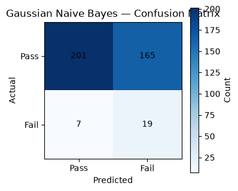

```python
nb_pipe = ImbPipeline([
    ("preprocess", SensorPreprocessor()),
    ("scale", StandardScaler()),
    ("smote", SMOTE(random_state=RANDOM_STATE)),
    ("model", GaussianNB())
])

nb_grid = {
    "model__var_smoothing": np.logspace(-11, -7, 5)
}

nb_search = GridSearchCV(
    nb_pipe, nb_grid, cv=cv, scoring="f1", n_jobs=-1, refit=True
)
nb_search.fit(X_train, y_train)
evaluate_model("Gaussian Naive Bayes", nb_search)
```

<h3 id="5.5-Enhancement:-PCA-+-Random-Forest">5.5 Enhancement: PCA + Random Forest</h3>

```
===== Random Forest + PCA (95%) =====
Best parameters: {'model__max_depth': 10, 'model__n_estimators': 100}
Best 5-fold CV Fail-F1: 0.0000
Test Accuracy: 0.9337
Test Precision (Fail): 0.0000
Test Recall (Fail): 0.0000
Test F1 (Fail): 0.0000
Test ROC-AUC: 0.5387

              precision    recall  f1-score   support

   Pass (-1)       0.93      1.00      0.97       366
    Fail (1)       0.00      0.00      0.00        26

    accuracy                           0.93       392
   macro avg       0.47      0.50      0.48       392
weighted avg       0.87      0.93      0.90       392
```

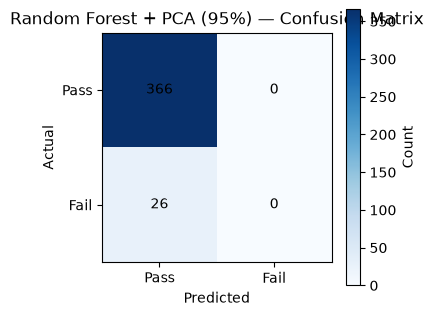

```
PCA components retained: 148
```

```python
rf_pca_pipe = ImbPipeline([
    ("preprocess", SensorPreprocessor()),
    ("scale", StandardScaler()),
    ("smote", SMOTE(random_state=RANDOM_STATE)),
    ("pca", PCA(n_components=0.95, random_state=RANDOM_STATE)),
    ("model", RandomForestClassifier(random_state=RANDOM_STATE, n_jobs=-1))
])

rf_pca_grid = {
    "model__n_estimators": [100, 200],
    "model__max_depth": [10, 20]
}

rf_pca_search = GridSearchCV(
    rf_pca_pipe, rf_pca_grid, cv=cv, scoring="f1", n_jobs=-1, refit=True
)
rf_pca_search.fit(X_train, y_train)
evaluate_model("Random Forest + PCA (95%)", rf_pca_search)

pca_step = rf_pca_search.best_estimator_.named_steps["pca"]
print("PCA components retained:", pca_step.n_components_)
```

<h2 id="6.-Model-Comparison-&-Final-Selection">6. Model Comparison & Final Selection</h2>

```python
# IMPORTANT: select using cross-validation on training data.
# The held-out test set remains independent for final performance reporting.
summary_df = pd.DataFrame(results).T[
    ["cv_fail_f1", "test_accuracy", "test_precision_fail",
     "test_recall_fail", "test_f1_fail", "test_roc_auc"]
].sort_values("cv_fail_f1", ascending=False)

display(summary_df.round(4))
```

<style scoped> .dataframe tbody tr th:only-of-type { vertical-align: middle; } .dataframe tbody tr th { vertical-align: top; } .dataframe thead th { text-align: right; } </style> <thead> <th></th> <th>cv_fail_f1</th> <th>test_accuracy</th> <th>test_precision_fail</th> <th>test_recall_fail</th> <th>test_f1_fail</th> <th>test_roc_auc</th> </thead> <tbody> <th>Logistic Regression</th> <th>Gaussian Naive Bayes</th> <th>SVM</th> <th>Random Forest</th> <th>Random Forest + PCA (95%)</th> </tbody>

| 0.2256 | 0.8444 | 0.1277 | 0.2308 | 0.1644 | 0.6612 |
| --- | --- | --- | --- | --- | --- |
| 0.1256 | 0.5612 | 0.1033 | 0.7308 | 0.1810 | 0.6670 |
| 0.1016 | 0.9184 | 0.2000 | 0.0769 | 0.1111 | 0.6894 |
| 0.0865 | 0.9286 | 0.3333 | 0.0769 | 0.1250 | 0.7859 |
| 0.0000 | 0.9337 | 0.0000 | 0.0000 | 0.0000 | 0.5387 |

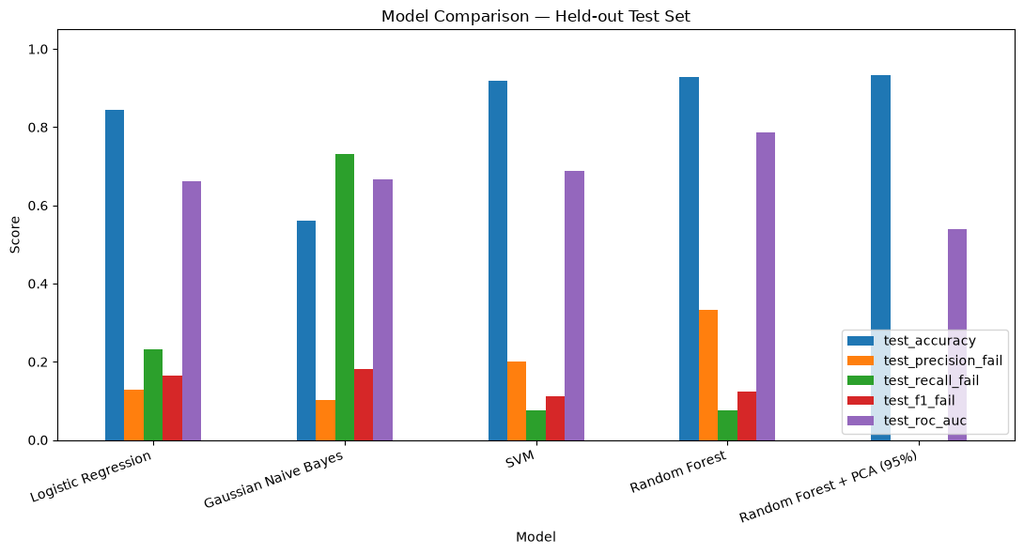

```python
plot_df = summary_df[[
    "test_accuracy", "test_precision_fail",
    "test_recall_fail", "test_f1_fail", "test_roc_auc"
]]

ax = plot_df.plot(kind="bar", figsize=(11,6))
ax.set_title("Model Comparison — Held-out Test Set")
ax.set_ylabel("Score")
ax.set_xlabel("Model")
ax.set_ylim(0, 1.05)
plt.xticks(rotation=20, ha="right")
plt.legend(loc="lower right")
plt.tight_layout()
plt.show()
```

```python
best_model_name = summary_df.index[0]
final_model = fitted_models[best_model_name]

print("Final model selected using highest 5-fold cross-validation Fail-F1:")
print(best_model_name)
print("\nFinal model test metrics:")
display(summary_df.loc[[best_model_name]].round(4))
```

```
Final model selected using highest 5-fold cross-validation Fail-F1:
Logistic Regression

Final model test metrics:
```

<style scoped> .dataframe tbody tr th:only-of-type { vertical-align: middle; } .dataframe tbody tr th { vertical-align: top; } .dataframe thead th { text-align: right; } </style> <thead> <th></th> <th>cv_fail_f1</th> <th>test_accuracy</th> <th>test_precision_fail</th> <th>test_recall_fail</th> <th>test_f1_fail</th> <th>test_roc_auc</th> </thead> <tbody> <th>Logistic Regression</th> </tbody>

| 0.2256 | 0.8444 | 0.1277 | 0.2308 | 0.1644 | 0.6612 |
| --- | --- | --- | --- | --- | --- |

<h3 id="Model-selection-rationale">Model selection rationale</h3><p>The final model is selected using the **highest Fail-class F1-score from 5-fold stratified cross-validation on the training data**. This avoids choosing a model based on repeated inspection of the held-out test set.</p> <p>F1 balances precision and recall for the minority Fail class. Test accuracy is still reported, but it is not used as the sole selection criterion because the dataset is strongly imbalanced. The final held-out test metrics therefore provide a cleaner estimate of generalisation performance.</p>

<h2 id="7.-Save-the-Selected-Model">7. Save the Selected Model</h2>

```python
os.makedirs("model", exist_ok=True)

model_path = "model/best_yield_prediction_pipeline.pkl"
joblib.dump(final_model, model_path)

# Save the model-selection summary and project metadata for future use.
summary_df.to_csv("model/model_comparison.csv")

metadata = {
    "random_state": RANDOM_STATE,
    "target_mapping": {"-1": "Pass", "1": "Fail"},
    "selection_metric": "5-fold cross-validation Fail-class F1",
    "selected_model": best_model_name,
    "raw_shape": df.shape,
    "train_shape": X_train.shape,
    "test_shape": X_test.shape
}
joblib.dump(metadata, "model/project_metadata.pkl")

print("Saved:")
print(" -", model_path)
print(" - model/model_comparison.csv")
print(" - model/project_metadata.pkl")
```

```
Saved:
 - model/best_yield_prediction_pipeline.pkl
 - model/model_comparison.csv
 - model/project_metadata.pkl
```

<h1 id="8.-Conclusion-&-Improvements">8. Conclusion & Improvements</h1>

1. <p>**Data quality:** The raw semiconductor dataset contains a large number of sensor variables, including missing, constant and highly redundant signals. Logical feature filtering reduces unnecessary dimensionality.</p>
2. <p>**Class imbalance:** Approximately 93% of entities are Pass and 7% are Fail. SMOTE is therefore applied only to training folds so the real test distribution remains unchanged.</p>
3. <p>**Leakage control:** Data-dependent cleansing, imputation, scaling, dimensionality reduction and SMOTE are contained inside the modelling pipelines. This ensures that cross-validation does not learn preprocessing statistics from validation/test observations.</p>
4. <p>**Model comparison:** Logistic Regression, Random Forest, SVM and Gaussian Naive Bayes are tuned using 5-fold stratified GridSearchCV. A PCA-enhanced Random Forest is included as a dimensionality-reduction enhancement.</p>
5. <p>**Model selection:** The final model is selected using training cross-validation Fail-F1 rather than test-set performance. The held-out test set is used only for final reporting.</p>
6. <p>**Feature reduction:** The PCA experiment directly investigates whether a compressed representation can preserve useful predictive information, addressing the project question of whether every measured signal is necessary.</p>

<h3 id="Future-improvements">Future improvements</h3>

- Tune the decision threshold using a validation set if the business cost of missed Fails versus false alarms is known.
- Add model explainability such as permutation importance or SHAP to support process-engineer investigation.
- Validate the selected pipeline on data from a later production period to measure temporal robustness.
- Monitor data drift and recalibrate/retrain the model as manufacturing conditions change.

<p>**Final takeaway:** The workflow provides a reproducible, leakage-aware machine-learning pipeline for semiconductor yield prediction, while explicitly accounting for class imbalance, high dimensionality and the need to detect Fail events</p>